# Introduction to Machine Learning Exercise 1

# Problem 1

### a)

$$\begin{align*}
\alpha &= 2e^{-2n\epsilon^2} \\
\Rightarrow \ln\alpha &= \ln 2 -2n\epsilon^2 \\
\Rightarrow \epsilon &= \pm\sqrt{\frac{\ln 2-\ln\alpha}{2n}}.
\end{align*}$$

The negative solution can be ignored because $\epsilon\geq 0$. The width of the interval $[n(p-\epsilon),n(p+\epsilon)]$ is then
$$n(p+\epsilon)-n(p-\epsilon)=2n\epsilon=\sqrt{2n(\ln 2-\ln\alpha)}.$$
For $n=10,100,1000$ and $\alpha=0.05$ we get the following values for the width:

| n | width |
| --- | --- |
| 10 | 8.589388 |
| 100 | 27.162030 |
| 1000 | 85.893882 |

### b)

Define a function to calculate the confidence intervals for any $n,p$ with $\alpha=0.05$:

```r
confidence_interval <- function(n, p) {
  alpha <- 0.05
  epsilon <- sqrt((log(2)-log(alpha))/(2*n))
  return(c(n*(p-epsilon), n*(p+epsilon)))
}
```

Next we define a function to return the fraction of outcomes inside a given interval out of all repetitions:

```r
interval_test <- function(n, p) {
  alpha <- 0.05
  repetitions <- 10000
  values <- rbinom(10000, n, p)
  interval <- confidence_interval(n, p)
  count <- 0 #number of outcomes inside a given interval

  for (i in values) {
    if (i >= interval[1] && i <= interval[2]) {
      count <- count + 1
    }
  }
  return(count/repetitions)
}
```

Finally, we run the above function for $n=10,100,1000$ and $p=0.5,0.9,0.99$.

```r
n <- c(10, 100, 1000)
p <- c(0.5, 0.9, 0.99)

for (i in n) {
  for (j in p) {
    cat("\t n =", i, "\t p =", j, "\t fraction =", interval_test(i,j), "\n", sep = " ")
  }
}
```

```
##   n = 10      p = 0.5     fraction = 0.9982
##   n = 10      p = 0.9     fraction = 0.9999
##   n = 10      p = 0.99    fraction = 1
##   n = 100     p = 0.5     fraction = 0.9925
##   n = 100     p = 0.9     fraction = 1
##   n = 100     p = 0.99    fraction = 1
##   n = 1000    p = 0.5     fraction = 0.9934
##   n = 1000    p = 0.9     fraction = 1
##   n = 1000    p = 0.99    fraction = 1
```

As expected, all fractions are greater than 95 %.

### c)

Now we have
$$P(\bigcup_{i=1}^k A_i)\leq \sum_{i=1}^k P(A_i)\leq 2e^{-2n\epsilon^2}=2ke^{-2n\epsilon^2}.$$
Set this equal to $\alpha$ and solve for $\epsilon$
$$\begin{align*}
\alpha &= 2ke^{-2n\epsilon^2} \\
\Rightarrow \ln\alpha &= \ln 2k -2n\epsilon^2 \\
\Rightarrow \epsilon &= \sqrt{\frac{\ln 2k-\ln\alpha}{2n}}.
\end{align*}$$

Thus the width of the interval $[n(p-\epsilon),n(p+\epsilon)]$ is
$$n(p+\epsilon)-n(p-\epsilon)=2n\epsilon=\sqrt{2n(\ln 2k-\ln\alpha)}.$$
Increasing the number of classifiers $k$ widens the confidence interval, but quite slowly ($\mathcal{O}(\sqrt{\ln k})$) compared to increasing the sample size $n$. The widths for $n=10,100,1000$ and $k=1,10,100$ are given in the table below.

|  | k=1 | k=10 | k=100 |
| --- | --- | --- | --- |
| n=10 | 8.589388 | 10.94666 | 12.87948 |
| n=100 | 27.162030 | 34.61637 | 40.72849 |
| n=1000 | 85.893882 | 109.46657 | 128.79480 |

### d)

Repeat the process we did previously, but draw $k=1,10,100$ binomial values instead of $10000$.

```r
confidence_interval <- function(n, p, k) {
  alpha <- 0.05
  epsilon <- sqrt((log(2*k)-log(alpha))/(2*n))
  return(c(n*(p-epsilon), n*(p+epsilon)))
}
```

```r
interval_test <- function(n, p, k) {
  alpha <- 0.05
  repetitions <- 10000

  count <- 0

  for (rep in 1:repetitions) {
    values <- rbinom(k, n, p) #draw k binomial values
    interval <- confidence_interval(n,p,k)

    #increment counter only if all values drawn are inside the confidence interval
    if (length(values[values <= interval[2] && values >= interval[1]]) == k) {
          count <- count + 1
        }
  }
  return(count/repetitions)
}
```

Finally, we run the above function for $n=10,100,1000$, $p=0.5,0.9,0.99$ and $k=1,10,100$.

```r
n <- c(10, 100, 1000)
p <- c(0.5, 0.9, 0.99)
k <- c(1,10, 100)

for (i in n) {
  for (j in p) {
    for (l in k) {
      cat("\t n =", i, "\t p =", j, "\t k =", l, "\t fraction =",
          interval_test(i,j,l), "\n", sep = " ")
    }
  }
}
```

```
##   n = 10      p = 0.5     k = 1   fraction = 0.9981
##   n = 10      p = 0.5     k = 10      fraction = 1
##   n = 10      p = 0.5     k = 100     fraction = 1
##   n = 10      p = 0.9     k = 1   fraction = 1
##   n = 10      p = 0.9     k = 10      fraction = 1
##   n = 10      p = 0.9     k = 100     fraction = 1
##   n = 10      p = 0.99    k = 1   fraction = 1
##   n = 10      p = 0.99    k = 10      fraction = 1
##   n = 10      p = 0.99    k = 100     fraction = 1
##   n = 100     p = 0.5     k = 1   fraction = 0.9923
##   n = 100     p = 0.5     k = 10      fraction = 0.9997
##   n = 100     p = 0.5     k = 100     fraction = 0.9999
##   n = 100     p = 0.9     k = 1   fraction = 1
##   n = 100     p = 0.9     k = 10      fraction = 1
##   n = 100     p = 0.9     k = 100     fraction = 1
##   n = 100     p = 0.99    k = 1   fraction = 1
##   n = 100     p = 0.99    k = 10      fraction = 1
##   n = 100     p = 0.99    k = 100     fraction = 1
##   n = 1000    p = 0.5     k = 1   fraction = 0.9925
##   n = 1000    p = 0.5     k = 10      fraction = 0.9995
##   n = 1000    p = 0.5     k = 100     fraction = 1
##   n = 1000    p = 0.9     k = 1   fraction = 1
##   n = 1000    p = 0.9     k = 10      fraction = 1
##   n = 1000    p = 0.9     k = 100     fraction = 1
##   n = 1000    p = 0.99    k = 1   fraction = 1
##   n = 1000    p = 0.99    k = 10      fraction = 1
##   n = 1000    p = 0.99    k = 100     fraction = 1
```

Again all fractions are greater than 95 %.

# Problem 2

### a)

```r
college <- read.csv("College.csv")
```

### b)

```r
college
```

| X | Private | Apps | Accept | Enroll | Top10perc | Top25perc | F.Undergrad | P.Undergrad | Outstate | Room.Board | Books | Personal | PhD | Terminal | S.F.Ratio | perc.alumni | Expend | Grad.Rate |
| --- | --- | --- | --- | --- | --- | --- | --- | --- | --- | --- | --- | --- | --- | --- | --- | --- | --- | --- |
| Abilene Christian University | Yes | 1660 | 1232 | 721 | 23 | 52 | 2885 | 537 | 7440 | 3300 | 450 | 2200 | 70 | 78 | 18.1 | 12 | 7041 | 60 |
| Adelphi University | Yes | 2186 | 1924 | 512 | 16 | 29 | 2683 | 1227 | 12280 | 6450 | 750 | 1500 | 29 | 30 | 12.2 | 16 | 10527 | 56 |
| Adrian College | Yes | 1428 | 1097 | 336 | 22 | 50 | 1036 | 99 | 11250 | 3750 | 400 | 1165 | 53 | 66 | 12.9 | 30 | 8735 | 54 |
| Agnes Scott College | Yes | 417 | 349 | 137 | 60 | 89 | 510 | 63 | 12960 | 5450 | 450 | 875 | 92 | 97 | 7.7 | 37 | 19016 | 59 |
| Alaska Pacific University | Yes | 193 | 146 | 55 | 16 | 44 | 249 | 869 | 7560 | 4120 | 800 | 1500 | 76 | 72 | 11.9 | 2 | 10922 | 15 |
| Albertson College | Yes | 587 | 479 | 158 | 38 | 62 | 678 | 41 | 13500 | 3335 | 500 | 675 | 67 | 73 | 9.4 | 11 | 9727 | 55 |
| Albertus Magnus College | Yes | 353 | 340 | 103 | 17 | 45 | 416 | 230 | 13290 | 5720 | 500 | 1500 | 90 | 93 | 11.5 | 26 | 8861 | 63 |
| Albion College | Yes | 1899 | 1720 | 489 | 37 | 68 | 1594 | 32 | 13868 | 4826 | 450 | 850 | 89 | 100 | 13.7 | 37 | 11487 | 73 |
| Albright College | Yes | 1038 | 839 | 227 | 30 | 63 | 973 | 306 | 15595 | 4400 | 300 | 500 | 79 | 84 | 11.3 | 23 | 11644 | 80 |
| Alderson-Broaddus College | Yes | 582 | 498 | 172 | 21 | 44 | 799 | 78 | 10468 | 3380 | 660 | 1800 | 40 | 41 | 11.5 | 15 | 8991 | 52 |

[output cut: 767 more lines]

```r
rownames(college)=college[,1]
college
```

|  | X | Private | Apps | Accept | Enroll | Top10perc | Top25perc | F.Undergrad | P.Undergrad | Outstate | Room.Board | Books | Personal | PhD | Terminal | S.F.Ratio | perc.alumni | Expend | Grad.Rate |
| --- | --- | --- | --- | --- | --- | --- | --- | --- | --- | --- | --- | --- | --- | --- | --- | --- | --- | --- | --- |
| Abilene Christian University | Abilene Christian University | Yes | 1660 | 1232 | 721 | 23 | 52 | 2885 | 537 | 7440 | 3300 | 450 | 2200 | 70 | 78 | 18.1 | 12 | 7041 | 60 |
| Adelphi University | Adelphi University | Yes | 2186 | 1924 | 512 | 16 | 29 | 2683 | 1227 | 12280 | 6450 | 750 | 1500 | 29 | 30 | 12.2 | 16 | 10527 | 56 |
| Adrian College | Adrian College | Yes | 1428 | 1097 | 336 | 22 | 50 | 1036 | 99 | 11250 | 3750 | 400 | 1165 | 53 | 66 | 12.9 | 30 | 8735 | 54 |
| Agnes Scott College | Agnes Scott College | Yes | 417 | 349 | 137 | 60 | 89 | 510 | 63 | 12960 | 5450 | 450 | 875 | 92 | 97 | 7.7 | 37 | 19016 | 59 |
| Alaska Pacific University | Alaska Pacific University | Yes | 193 | 146 | 55 | 16 | 44 | 249 | 869 | 7560 | 4120 | 800 | 1500 | 76 | 72 | 11.9 | 2 | 10922 | 15 |
| Albertson College | Albertson College | Yes | 587 | 479 | 158 | 38 | 62 | 678 | 41 | 13500 | 3335 | 500 | 675 | 67 | 73 | 9.4 | 11 | 9727 | 55 |
| Albertus Magnus College | Albertus Magnus College | Yes | 353 | 340 | 103 | 17 | 45 | 416 | 230 | 13290 | 5720 | 500 | 1500 | 90 | 93 | 11.5 | 26 | 8861 | 63 |
| Albion College | Albion College | Yes | 1899 | 1720 | 489 | 37 | 68 | 1594 | 32 | 13868 | 4826 | 450 | 850 | 89 | 100 | 13.7 | 37 | 11487 | 73 |
| Albright College | Albright College | Yes | 1038 | 839 | 227 | 30 | 63 | 973 | 306 | 15595 | 4400 | 300 | 500 | 79 | 84 | 11.3 | 23 | 11644 | 80 |
| Alderson-Broaddus College | Alderson-Broaddus College | Yes | 582 | 498 | 172 | 21 | 44 | 799 | 78 | 10468 | 3380 | 660 | 1800 | 40 | 41 | 11.5 | 15 | 8991 | 52 |

[output cut: 767 more lines]

```r
college=college[,-1]
college
```

|  | Private | Apps | Accept | Enroll | Top10perc | Top25perc | F.Undergrad | P.Undergrad | Outstate | Room.Board | Books | Personal | PhD | Terminal | S.F.Ratio | perc.alumni | Expend | Grad.Rate |
| --- | --- | --- | --- | --- | --- | --- | --- | --- | --- | --- | --- | --- | --- | --- | --- | --- | --- | --- |
| Abilene Christian University | Yes | 1660 | 1232 | 721 | 23 | 52 | 2885 | 537 | 7440 | 3300 | 450 | 2200 | 70 | 78 | 18.1 | 12 | 7041 | 60 |
| Adelphi University | Yes | 2186 | 1924 | 512 | 16 | 29 | 2683 | 1227 | 12280 | 6450 | 750 | 1500 | 29 | 30 | 12.2 | 16 | 10527 | 56 |
| Adrian College | Yes | 1428 | 1097 | 336 | 22 | 50 | 1036 | 99 | 11250 | 3750 | 400 | 1165 | 53 | 66 | 12.9 | 30 | 8735 | 54 |
| Agnes Scott College | Yes | 417 | 349 | 137 | 60 | 89 | 510 | 63 | 12960 | 5450 | 450 | 875 | 92 | 97 | 7.7 | 37 | 19016 | 59 |
| Alaska Pacific University | Yes | 193 | 146 | 55 | 16 | 44 | 249 | 869 | 7560 | 4120 | 800 | 1500 | 76 | 72 | 11.9 | 2 | 10922 | 15 |
| Albertson College | Yes | 587 | 479 | 158 | 38 | 62 | 678 | 41 | 13500 | 3335 | 500 | 675 | 67 | 73 | 9.4 | 11 | 9727 | 55 |
| Albertus Magnus College | Yes | 353 | 340 | 103 | 17 | 45 | 416 | 230 | 13290 | 5720 | 500 | 1500 | 90 | 93 | 11.5 | 26 | 8861 | 63 |
| Albion College | Yes | 1899 | 1720 | 489 | 37 | 68 | 1594 | 32 | 13868 | 4826 | 450 | 850 | 89 | 100 | 13.7 | 37 | 11487 | 73 |
| Albright College | Yes | 1038 | 839 | 227 | 30 | 63 | 973 | 306 | 15595 | 4400 | 300 | 500 | 79 | 84 | 11.3 | 23 | 11644 | 80 |
| Alderson-Broaddus College | Yes | 582 | 498 | 172 | 21 | 44 | 799 | 78 | 10468 | 3380 | 660 | 1800 | 40 | 41 | 11.5 | 15 | 8991 | 52 |

[output cut: 767 more lines]

### c)

Print a summary of the data.

```r
summary(college)
```

```
##  Private        Apps           Accept          Enroll       Top10perc
##  No :212   Min.   :   81   Min.   :   72   Min.   :  35   Min.   : 1.00
##  Yes:565   1st Qu.:  776   1st Qu.:  604   1st Qu.: 242   1st Qu.:15.00
##            Median : 1558   Median : 1110   Median : 434   Median :23.00
##            Mean   : 3002   Mean   : 2019   Mean   : 780   Mean   :27.56
##            3rd Qu.: 3624   3rd Qu.: 2424   3rd Qu.: 902   3rd Qu.:35.00
##            Max.   :48094   Max.   :26330   Max.   :6392   Max.   :96.00
##    Top25perc      F.Undergrad     P.Undergrad         Outstate
##  Min.   :  9.0   Min.   :  139   Min.   :    1.0   Min.   : 2340
##  1st Qu.: 41.0   1st Qu.:  992   1st Qu.:   95.0   1st Qu.: 7320
##  Median : 54.0   Median : 1707   Median :  353.0   Median : 9990
##  Mean   : 55.8   Mean   : 3700   Mean   :  855.3   Mean   :10441
##  3rd Qu.: 69.0   3rd Qu.: 4005   3rd Qu.:  967.0   3rd Qu.:12925
##  Max.   :100.0   Max.   :31643   Max.   :21836.0   Max.   :21700
##    Room.Board       Books           Personal         PhD
##  Min.   :1780   Min.   :  96.0   Min.   : 250   Min.   :  8.00
##  1st Qu.:3597   1st Qu.: 470.0   1st Qu.: 850   1st Qu.: 62.00
##  Median :4200   Median : 500.0   Median :1200   Median : 75.00
##  Mean   :4358   Mean   : 549.4   Mean   :1341   Mean   : 72.66
##  3rd Qu.:5050   3rd Qu.: 600.0   3rd Qu.:1700   3rd Qu.: 85.00
##  Max.   :8124   Max.   :2340.0   Max.   :6800   Max.   :103.00
##     Terminal       S.F.Ratio      perc.alumni        Expend
##  Min.   : 24.0   Min.   : 2.50   Min.   : 0.00   Min.   : 3186
##  1st Qu.: 71.0   1st Qu.:11.50   1st Qu.:13.00   1st Qu.: 6751
##  Median : 82.0   Median :13.60   Median :21.00   Median : 8377
##  Mean   : 79.7   Mean   :14.09   Mean   :22.74   Mean   : 9660
##  3rd Qu.: 92.0   3rd Qu.:16.50   3rd Qu.:31.00   3rd Qu.:10830
##  Max.   :100.0   Max.   :39.80   Max.   :64.00   Max.   :56233
##    Grad.Rate
##  Min.   : 10.00
##  1st Qu.: 53.00
##  Median : 65.00
##  Mean   : 65.46
##  3rd Qu.: 78.00
##  Max.   :118.00
```

Produce a scatterplot matrix of the first 10 columns of the data.

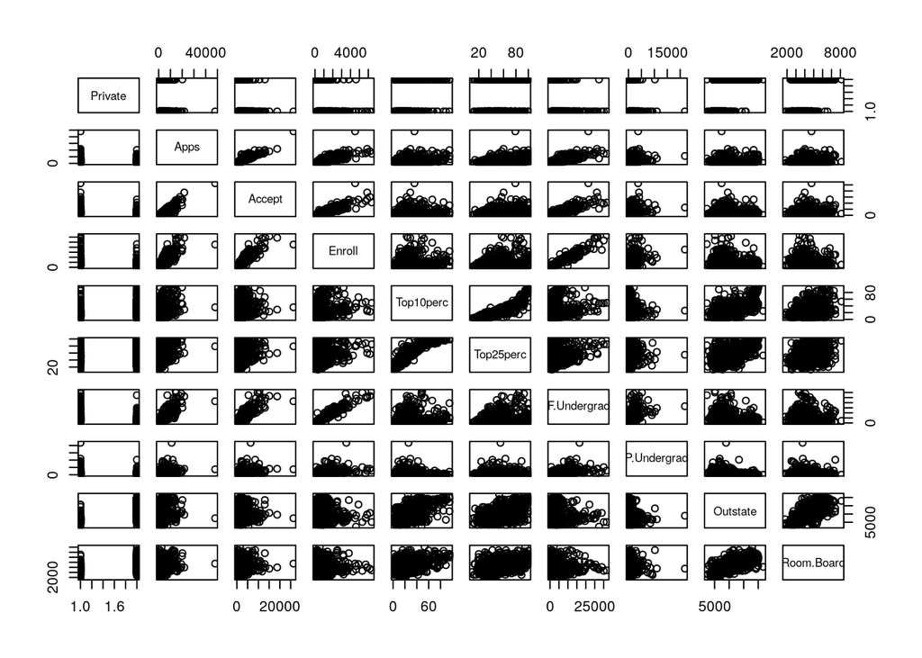

```r
pairs(college[,1:10])
```

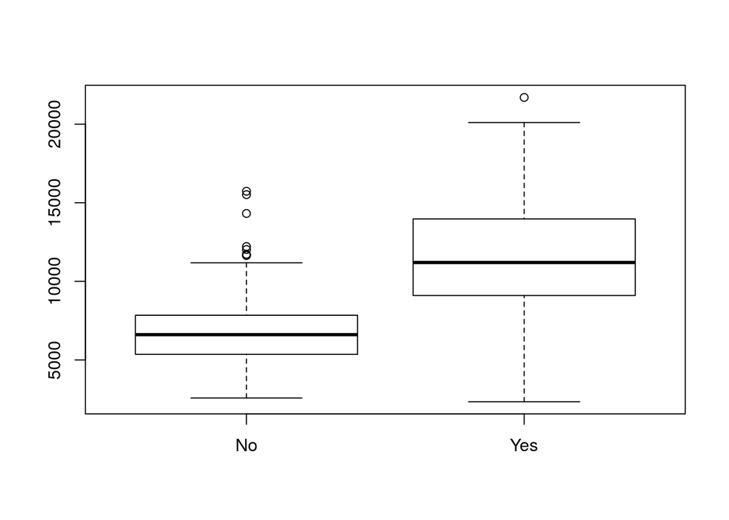

```r
plot(college$Private, college$Outstate)
```

Create the new variable `Elite` as instucted.

```r
Elite=rep("No",nrow(college))
Elite[college$Top10perc >50]="Yes"
Elite=as.factor(Elite)
college=data.frame(college,Elite)

summary(college)
```

```
##  Private        Apps           Accept          Enroll       Top10perc
##  No :212   Min.   :   81   Min.   :   72   Min.   :  35   Min.   : 1.00
##  Yes:565   1st Qu.:  776   1st Qu.:  604   1st Qu.: 242   1st Qu.:15.00
##            Median : 1558   Median : 1110   Median : 434   Median :23.00
##            Mean   : 3002   Mean   : 2019   Mean   : 780   Mean   :27.56
##            3rd Qu.: 3624   3rd Qu.: 2424   3rd Qu.: 902   3rd Qu.:35.00
##            Max.   :48094   Max.   :26330   Max.   :6392   Max.   :96.00
##    Top25perc      F.Undergrad     P.Undergrad         Outstate
##  Min.   :  9.0   Min.   :  139   Min.   :    1.0   Min.   : 2340
##  1st Qu.: 41.0   1st Qu.:  992   1st Qu.:   95.0   1st Qu.: 7320
##  Median : 54.0   Median : 1707   Median :  353.0   Median : 9990
##  Mean   : 55.8   Mean   : 3700   Mean   :  855.3   Mean   :10441
##  3rd Qu.: 69.0   3rd Qu.: 4005   3rd Qu.:  967.0   3rd Qu.:12925
##  Max.   :100.0   Max.   :31643   Max.   :21836.0   Max.   :21700
##    Room.Board       Books           Personal         PhD
##  Min.   :1780   Min.   :  96.0   Min.   : 250   Min.   :  8.00
##  1st Qu.:3597   1st Qu.: 470.0   1st Qu.: 850   1st Qu.: 62.00
##  Median :4200   Median : 500.0   Median :1200   Median : 75.00
##  Mean   :4358   Mean   : 549.4   Mean   :1341   Mean   : 72.66
##  3rd Qu.:5050   3rd Qu.: 600.0   3rd Qu.:1700   3rd Qu.: 85.00
##  Max.   :8124   Max.   :2340.0   Max.   :6800   Max.   :103.00
##     Terminal       S.F.Ratio      perc.alumni        Expend
##  Min.   : 24.0   Min.   : 2.50   Min.   : 0.00   Min.   : 3186
##  1st Qu.: 71.0   1st Qu.:11.50   1st Qu.:13.00   1st Qu.: 6751
##  Median : 82.0   Median :13.60   Median :21.00   Median : 8377
##  Mean   : 79.7   Mean   :14.09   Mean   :22.74   Mean   : 9660
##  3rd Qu.: 92.0   3rd Qu.:16.50   3rd Qu.:31.00   3rd Qu.:10830
##  Max.   :100.0   Max.   :39.80   Max.   :64.00   Max.   :56233
##    Grad.Rate      Elite
##  Min.   : 10.00   No :699
##  1st Qu.: 53.00   Yes: 78
##  Median : 65.00
##  Mean   : 65.46
##  3rd Qu.: 78.00
##  Max.   :118.00
```

There appears to be 78 elite universities. Now produce the boxplots.

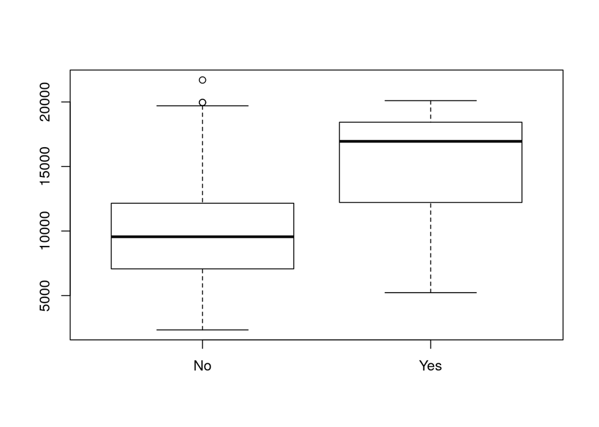

```r
plot(college$Elite, college$Outstate)
```

Let’s make four histograms of the acceptance rate with differing numbers of bins.

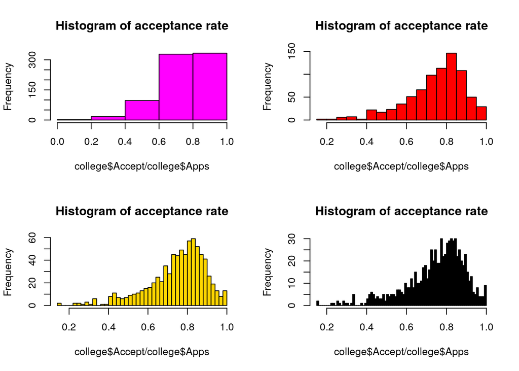

```r
par(mfrow=c(2,2))

title <- "Histogram of acceptance rate"
hist(college$Accept/college$Apps, breaks = 5, col = "magenta", main = title)
hist(college$Accept/college$Apps, breaks = 25, col = "red", main = title)
hist(college$Accept/college$Apps, breaks = 50, col = "gold", main = title)
hist(college$Accept/college$Apps, breaks = 100, col = "gray0", main = title)
```

```r
par(mfrow=c(1,1)) #set the graphics parameter back to default
```

# Problem 3

### a)

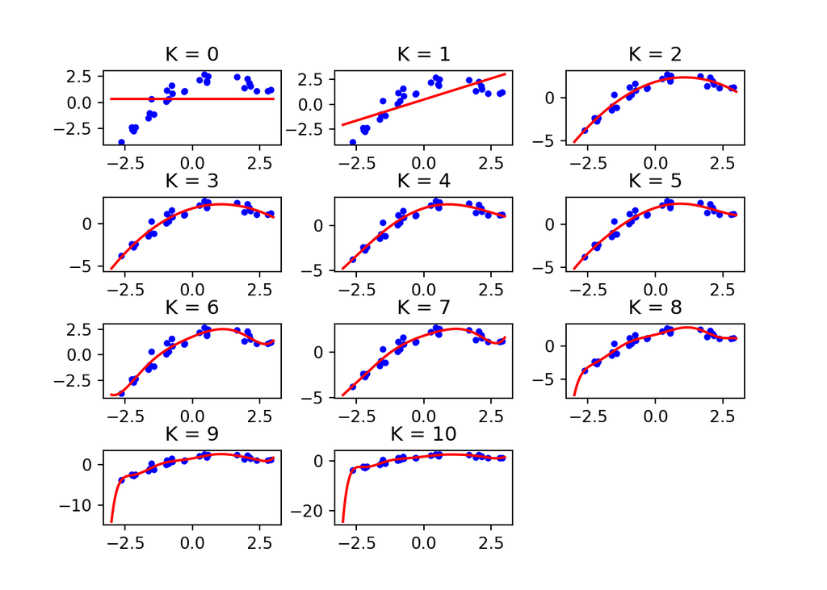

```python
import numpy as np
import matplotlib.pyplot as plt
np.random.seed(123456)
x = np.random.uniform(-3.0, 3.0, 30)
y = 2 + x - 0.5*np.power(x, 2) + np.random.normal(0.0, 0.4, 30)
interval = np.linspace(-3.0,3.0, 1000)
MSE = np.zeros(11)
models = []
for k in range(11):
  coefs, res, _, _, _ = np.polyfit(x, y, deg = k, full = True)
  MSE[k] = res/len(y)
  fit = np.poly1d(coefs)
  models.append(fit)
  plt.subplot(4, 3, k+1)
  plt.plot(x,y, '.b', interval, fit(interval), 'r-')
  plt.title("K = %d" % k)

plt.subplots_adjust(wspace = 0.3, hspace = 0.7)
plt.show()
```

```python
plt.close()
```

Plot the MSE as a function of $K$.

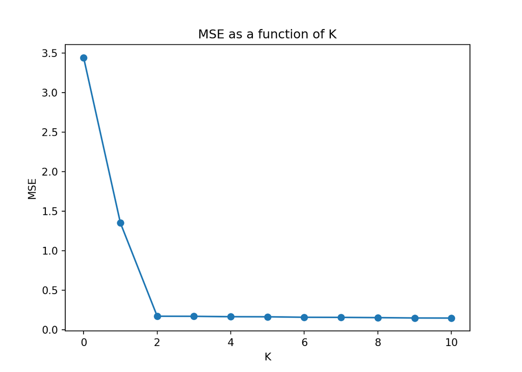

```python
plt.plot(range(11), MSE, 'o-', label = "Training")
plt.title("MSE as a function of K")
plt.xlabel("K")
plt.ylabel("MSE")
plt.show()
```

### b)

Generate a test set.

```python
x_test = np.random.uniform(-3.0, 3.0, 1000)
y_test = 2 + x_test - 0.5*np.power(x_test, 2) + np.random.normal(0.0, 0.4, 1000)
```

Calculate the test MSE and compare to the training MSE.

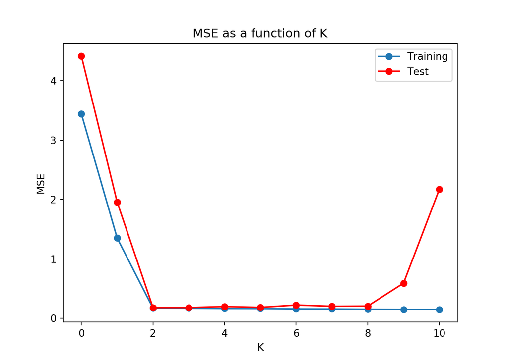

```python
#Computes the (mean) squared error
def computeSqErr(y, yhat, n = 1):
  return(np.sum(np.power(np.subtract(y,yhat),2))/n)

MSE_test = np.zeros(11)
for k in range(11):
  MSE_test[k] = computeSqErr(y_test, models[k](x_test), len(y_test))

plt.plot(range(11), MSE_test, 'ro-', label = "Test")
plt.legend()
plt.show()
```

```python
plt.close()
```

The training error decreases as $K$ increases, but the test error seems to increase as $K>2$, at least when $K$ is close to 10.

### c)

```python
y_split = np.split(y, 10)
x_split = np.split(x, 10)
SqErr = np.zeros(11)
for k in range(11):
  SqErr_k = 0
  for j in range(10):

    x_train = np.ndarray.flatten(np.delete(x_split, j, axis = 0))
    y_train = np.ndarray.flatten(np.delete(y_split, j, axis = 0))
    x_test = x_split[j]
    y_test = y_split[j]

    coeffs = np.polyfit(x_train, y_train, deg = k)
    fit = np.poly1d(coeffs)
    SqErr_k += computeSqErr(y_test, fit(x_test))

  SqErr[k] = SqErr_k
```

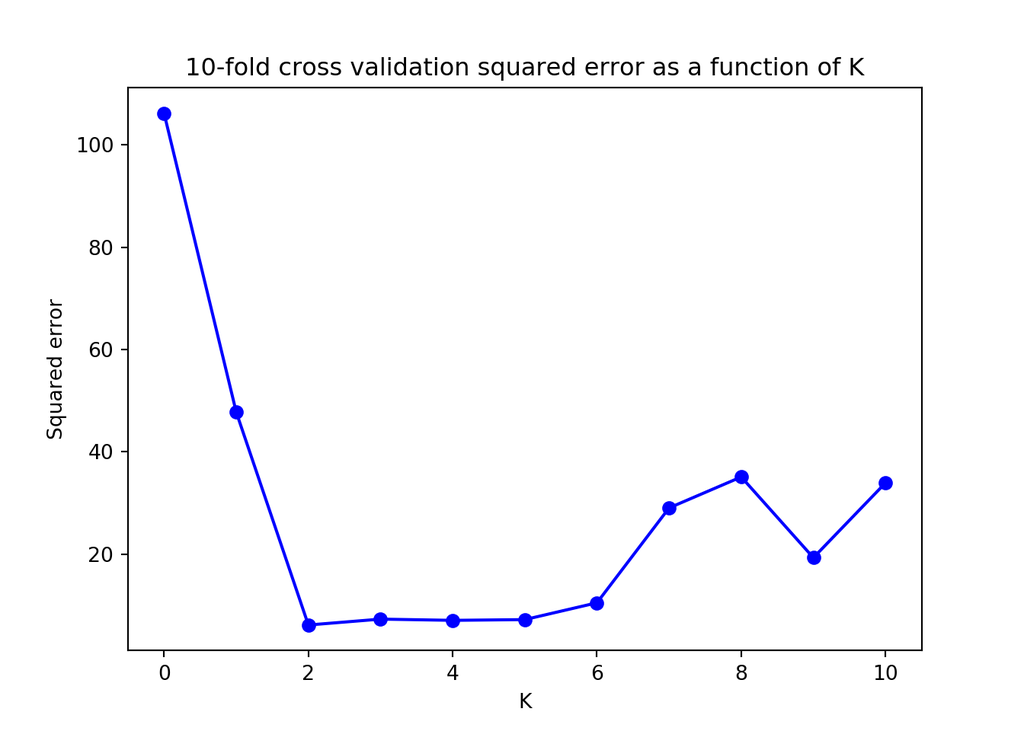

```python
plt.plot(range(11), SqErr, "-bo")
plt.xlabel("K")
plt.ylabel("Squared error")
plt.title("10-fold cross validation squared error as a function of K")
plt.show()
```

```python
plt.close()
print("The minimum error is given by K = %d" % np.argmin(SqErr))
```

```
## The minimum error is given by K = 2
```

The cross-validated error decreases first, and increases for $K>2$. The minimum error is given by $K=2$, which sounds reasonable since the generated polynomial $y$ is of order 2.